# Trabajo Final Análisis de Datos con R Intermedio

- Mostrar todo el código
- Ocultar todo el código
- Ver el código fuente

Autor/a

Felipe Sandoval S., Juan Garcés S.

Fecha de publicación

12 de diciembre de 2025

# Introducción

El Censo de Población y Vivienda 2024 se realizó en Chile entre los meses de marzo y julio, destacándose por ser el operativo estadístico más grande llevado a cabo por el Instituto Nacional de Estadísticas (INE) y por constituir un megaproyecto nacional en términos humanos y logísticos.

En la implementación del Censo 2024 se incorporaron avances tecnológicos y metodológicos significativos, entre los cuales destacan dos innovaciones principales: (i) el uso de herramientas tecnológicas para la recolección y su monitoreo; y (ii) la realización de un censo de mayor duración, orientado a la medición de la residencia habitual, conocido como censo de derecho. Este enfoque permitió obtener un registro actualizado de la cantidad de personas que residen en el país, así como su distribución territorial y condiciones de vida.

Contar con datos censales en materias como fecundidad, envejecimiento y migración, entre otras, resulta fundamental para la formulación y evaluación de políticas públicas y privadas en ámbitos esenciales para el desarrollo nacional, tales como vivienda, infraestructura sanitaria, salud, educación, empleo y pensiones.

Los resultados del censo se encuentran en https://censo2024.ine.gob.cl/.

En este informe se anañizan puntualmente variables asociadas a la situación en la fuerza de trabajo de las personas de 15 años y más para las comunas de la Región del Biobío. Esta información es frecuentemente pedida por las comunas, ya que la Encuesta Nacional de Empleo (ENE) que es el instrumento oficial diseñado para caracterizar a la población en edad de trabajar (PET), es una operación estadística que se basa en una muestra probabilística cuyos niveles de estimación llegan hasta el nivel provincial y algunas conurbaciones, pero no a nivel comunal. Mayores antecedentes en https://www.ine.gob.cl/estadisticas/sociales/mercado-laboral/ocupacion-y-desocupacion.

Es importante señalar que los análisis y resultados **no tienen el caracter de publicacion estadística oficial** y se hacen solo con fines educativos para cumplir requisitos del Curso de R Intermedio.

# Conceptos previos

Como se mencionó, se presentarSe presentarán las tasas de ocupación, desocupación y participación laboral por comunas de la Región del Biobío, para ambos sexos, hombres y mujeres, basándose en los resultados del Censo 2024. Previamente, es pertinente definir estos indicadores.

La **tasa de desocupación** se define como:

$$\text{tasa de desocupación}= \frac{\text{total de personas desocupadas}}{\text{total de personas ocupadas + total de personas desocupadas}} \cdot 100\%$$

Por su parte, la **tasa de ocupación** se define de la siguiente forma:

$$\text{tasa de ocupación}= \frac{\text{total de personas ocupadas}}{\text{total de personas en edad de trabajar (15 años de edad o más)}} \cdot 100\%$$

Finalmente, la **tasa de participación** se define:

$$\text{tasa de participación}= \frac{\text{total de personas ocupadas+total de personas desocupadas}}{\text{total de personas en edad de trabajar (15 años de edad o más)}} \cdot 100\%$$

# Carga y Preparación de los datos

Se utilizará la base de datos de personas del censo 2024, que en diciembre de 2025 se publicó a nivel de comuna.

El Manual de uso de la base de datos, el archivo csv y el diccionario de variables se descargan en el siguiente [Enlace](https://censo2024.ine.gob.cl/resultados/) (Se debe ir a descargar microdato Personas Censo 2024 (csv), descomprimirlo y pegarlo en la carpeta datos del proyecto, para que ejecutar correctamente el código).

## Carga de paquetes

Los paquetes que se utilizarán se cargan a continuación

**Mostrar/ocultar código**

```r
if(!require("arrow")){install.packages("arrow")}      ### Se utiliza el paquete arrow como lo recomienda el manual
if(!require("dplyr")){install.packages("dplyr")}      ### Manipulación de datos, filter(), select(), mutate(), etc
if(!require("purrr")){install.packages("purrr")}      ### iteraciones de funciones sobre listas, vectorses, df, etc.
if(!require("tidyr")){install.packages("tidyr")}        ###  ordenar y reestructurar datos, pivot_longer(), pivot_wider(), etc.
if(!require("ggplot2")){install.packages("ggplot2")}      ### Graficos
if(!require("here")){install.packages("here")}  ###para trabajar mejor con las rutas
```

## Carga de datos

Según el manual de uso de microdatos, se utilizará el paquete `arrow` , que brinda mayor eficiencia para usar archivos de gran tamaño. Primero se prepara un elemento llamado `schema`, con las características de las variables y posteriormente se abre el archivo csv, y las variables de interés, se colectan a través de la función `collect()`, pudiendo usarse la sintaxis de `dplyr`.

**Mostrar/ocultar código**

```r
personas_censo2024_schema <- schema(   ### Esquema de la tabla persona especificado en el punto 7.1.4.3. del manual.
  id_vivienda=int64(),
  id_hogar = int64(),
  id_persona = int64(),
  region = int64(),
  provincia = int64(),
  comuna = int64(),
  comuna_bajo_umbral = int64(),
  area = int64(),
  tipo_operativo = int64(),
  sexo = int64(),
  edad = int64(),
  edad_quinquenal = int64(),
  parentesco = int64(),
  p23_est_civil = int64(),
  p24_lug_resid5 = int64(),
  p24_lug_resid5_esp = int64(),
  p25_lug_nacimiento = int64(),
  p25_lug_nacimiento_rec = int64(),
  p25_lug_nacimiento_esp = int64(),
  p26_llegada_periodo = int64(),
  p27_nacionalidad = int64(),
  p27_nacionalidad_esp = int64(),
  p27_nacionalidad_rec = int64(),
  p28_autoid_pueblo = int64(),
  p28_pueblo_pert = int64(),
  p29_afrodescendencia_rec = int64(),
  p29_afrodescendencia = int64(),
  p30_lengua_indigena = int64(),
  p30_lengua_indigena_rec = int64(),
  p31_religion = int64(),
  p31_religion_rec = int64(),
  p32a_dificultad_ver = int64(),
  p32b_dificultad_oir = int64(),
  p32c_dificultad_mover = int64(),
  p32d_dificultad_cogni = int64(),
  p32e_dificultad_cuidado = int64(),
  p32f_dificultad_comunic = int64(),
  discapacidad = int64(),
  p33_edu_asiste = int64(),
  asistencia_parv = int64(),
  asistencia_basica = int64(),
  asistencia_media = int64(),
  asistencia_superior = int64(),
  p37_alfabet = int64(),
  escolaridad = int64(),
  cine11 = int64(),
  sit_fuerza_trabajo = int64(),
  p40_cise_rec = int64(),
  depend_econ_deficit_hab = int64(),
  cod_ciuo = int64(),
  cod_caenes = string(),
  p44_lug_trab = int64(),
  p44_lug_trab_esp = int64(),
  p45_medio_transporte = int64(),
  p46a_tot_hijs_nac = int64(),
  p46b_hijas_nac = int64(),
  p46c_hijos_nac = int64(),
  p47a_tot_hijs_sobrev = int64(),
  p47b_hijas_sobrev = int64(),
  p47c_hijos_sobrev = int64(),
  p48_anio_nac_uh = int64(),
  p48_mes_nac_uh = int64(),
  div_genero = int64()
)

personas_censo2024 <-open_dataset(here("datos/personas_censo2024.csv"),     ### permite leer datos muy pesados en formato "lazy", para no utilizar toda la memoria
                                  format = "csv", delim = ";", schema = personas_censo2024_schema, skip = 1)


region <- personas_censo2024 %>%
        filter(region==8) %>%
        select(comuna, area,sit_fuerza_trabajo,edad, sexo, cod_caenes, p44_lug_trab ) %>%  ### se seleccionan algunas variables con las que se trabajaran
        collect()

region2 <- region %>% #### se agregan los labels segun los levels para que se entienda de mejor forma para el lector, que vea datos y no solo numeros
  mutate(
    area = factor(area,
                  levels = c(1, 2),
                  labels = c("Urbano", "Rural")),
    sexo = factor(sexo,
                  levels = c(1, 2),
                  labels = c("Hombres", "Mujeres")),
    sit_fuerza_trabajo = factor(sit_fuerza_trabajo,
                                levels = c(-99, 1, 2, 3),
                                labels = c("No responde",
                                           "Ocupado",
                                           "Desocupado",
                                           "Fuera de la fuerza de trabajo")),
    p44_lug_trab = factor(p44_lug_trab,
                          levels = c(-99, 1, 2, 3, 4, 5),
                          labels = c("No responde",
                                     "En su comuna, en la vivienda",
                                     "En su comuna, fuera de la vivienda",
                                     "En otra comuna",
                                     "En otro país",
                                     "Varias comunas o países"))
  )

##removemos para ahorrar memoria en una de esas

rm(personas_censo2024, personas_censo2024_schema)
```

Entonces, con el tibble region2, ya tiene la información filtrada para la Región del Biobío, con las etiquetas correspondientes. A continuación se presenta, a modo de ejemplo, las ptimeras 10 filas.

**Mostrar/ocultar código**

```r
head(region2, 10)
```

```
# A tibble: 10 × 7
   comuna area   sit_fuerza_trabajo           edad sexo  cod_caenes p44_lug_trab
    <int> <fct>  <fct>                       <int> <fct> <chr>      <fct>
 1   8301 Urbano Fuera de la fuerza de trab…    64 Muje… ""         <NA>
 2   8111 Rural  Ocupado                        33 Homb… "F"        En su comun…
 3   8111 Rural  Ocupado                        32 Muje… "Q"        En su comun…
 4   8111 Rural  <NA>                            4 Muje… ""         <NA>
 5   8111 Rural  <NA>                           10 Homb… ""         <NA>
 6   8111 Rural  <NA>                           12 Homb… ""         <NA>
 7   8111 Rural  Fuera de la fuerza de trab…    15 Homb… ""         <NA>
 8   8304 Rural  Fuera de la fuerza de trab…    69 Homb… ""         <NA>
 9   8304 Rural  Fuera de la fuerza de trab…    66 Muje… ""         <NA>
10   8101 Urbano Ocupado                        29 Muje… "999"      En otra com…
```

A continuación, se crean tablas para personas ocupadas, desocupadas y fuera de la fuerza de trabajo por comuna de la Región del Biobío. Se utilizarán posteriormente para crear gráficos y tablas.

**Mostrar/ocultar código**

```r
ocupados <- region %>%             ### tabla de ocupados cruda
            filter(sit_fuerza_trabajo==1)

desocupados <- region %>%              ### tabla de desocupados cruda
            filter(sit_fuerza_trabajo==2)

inactivos <- region %>%             ### tabla de inactivos cruda
            filter(sit_fuerza_trabajo==3)

menores15 <- region %>%            ### tabla de menores de 15 años que sirve para la validación de los NA correspondientes
            select(comuna, edad, sexo) %>%
            filter(edad<15) %>%
            group_by(comuna) %>%
            count(sexo)

sit_fdt_total <- region %>%    ### tabla de situación de la fuerza de trabajo sin desagregar por sexo
                  filter(!is.na(sit_fuerza_trabajo)) %>%
                  select(comuna, sit_fuerza_trabajo) %>%
                  group_by(comuna) %>%
                  count(sit_fuerza_trabajo)

sit_fdt <- region %>%         ### tabla de situación de la fuerza de trabajo desagregada por sexo
          filter(!is.na(sit_fuerza_trabajo)) %>%
          select( comuna, sit_fuerza_trabajo, sexo) %>%
          group_by(comuna, sit_fuerza_trabajo) %>%
          count(sexo)
```

# Inclusión de funciones

El siguiente código llama a un archivo dentro del proyecto en que están creadas algunas funciones útiles.

**Mostrar/ocultar código**

```r
 source( here("scripts/functions.R"))

#### se llama al script adicional de funciones, agregar que no son funcniones totalmente genéricas y que dependen de los resultados obtenidos antes en este mismo script
```

# Resultados

Es importante señalar que los cálculos que se realizan son en función de las personas que respondieron a las preguntas de situación laboral, es decir, se considerará como población en edad de trabajar a las personas de 15 años o más de edad y que hayan respondido efectivamente estas preguntas.

Para efectos de comparación, a continuación se presentan los indicadores para la Región del Biobío, para Ambos sexos, hombres y mujeres.

**Mostrar/ocultar código**

```r
resultados_region<-region2 %>% group_by(sit_fuerza_trabajo, sexo) %>% summarise(Total=n())


##Hombres
resultados_region_h<-filter(resultados_region, sexo=="Hombres")

resultados_region_h<-pivot_wider(resultados_region_h, names_from =sit_fuerza_trabajo, values_from = Total)

resultados_region_h$td<-resultados_region_h$Desocupado/(resultados_region_h$Desocupado+resultados_region_h$Ocupado)*100


resultados_region_h$to<-resultados_region_h$Ocupado /(resultados_region_h$Desocupado+resultados_region_h$Ocupado+resultados_region_h$`Fuera de la fuerza de trabajo`)*100

resultados_region_h$tp<-(resultados_region_h$Desocupado+resultados_region_h$Ocupado) /(resultados_region_h$Desocupado+resultados_region_h$Ocupado+resultados_region_h$`Fuera de la fuerza de trabajo`)*100


##Mujeres
resultados_region_m<-filter(resultados_region, sexo=="Mujeres")

resultados_region_m<-pivot_wider(resultados_region_m, names_from =sit_fuerza_trabajo, values_from = Total)

resultados_region_m$td<-resultados_region_m$Desocupado/(resultados_region_m$Desocupado+resultados_region_m$Ocupado)*100


resultados_region_m$to<-resultados_region_m$Ocupado /(resultados_region_m$Desocupado+resultados_region_m$Ocupado+resultados_region_m$`Fuera de la fuerza de trabajo`)*100

resultados_region_m$tp<-(resultados_region_m$Desocupado+resultados_region_m$Ocupado) /(resultados_region_m$Desocupado+resultados_region_m$Ocupado+resultados_region_m$`Fuera de la fuerza de trabajo`)*100


##Ambos Sexos

resultados_resumen <- resultados_region %>%
                      group_by(sit_fuerza_trabajo ) %>%
                      summarise(Total=sum(Total))

td_reg<-resultados_resumen$Total[3]/(resultados_resumen$Total[2]+resultados_resumen$Total[3])*100

to_reg<-resultados_resumen$Total[2]/(resultados_resumen$Total[2]+resultados_resumen$Total[3]+resultados_resumen$Total[4])*100

tp_reg<-(resultados_resumen$Total[2]+resultados_resumen$Total[3])/(resultados_resumen$Total[2]+resultados_resumen$Total[3]+resultados_resumen$Total[4])*100
```

  Ambos sexos: `49.3` %

  Hombres: `58.6` %

  Mujeres: `40.9` %
- **Tasa de Participación**

  Ambos sexos: `55` %

  Hombres: `66` %

  Mujeres: `45.1` %

A partir de los resultados anteriores, se aprecian brechas entre hombres y mujeres, que también se observan en los resultados de la Encuesta Nacional de Empleo, las bajas tasas de ocupación y participación de las mujeres, comparado con los hombres.

## Tasa de desocupación a nivel comunal

**Mostrar/ocultar código**

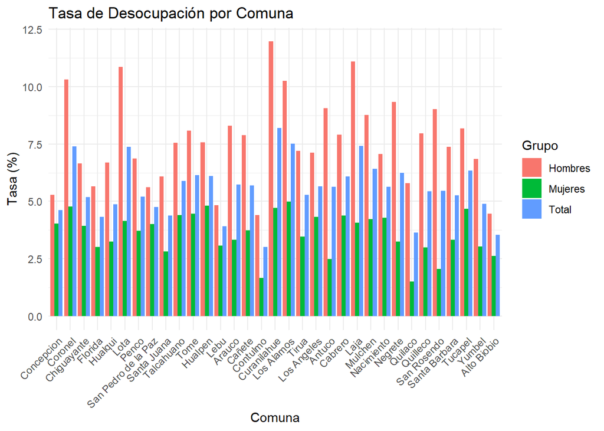

```r
codigos <- sort(unique(region2$comuna))   #### Para la uilizacion de la función map y derivados se necesita un orden que se obtienen a traves de estos codigos

df_d <- map_df(codigos, tasa_desocupacion) %>%   ### La función map_df itera una funcion sobre una lista de datos y los apila
        nombres_comuna(.) %>%
        pivot(.)

df_o <- map_df(codigos, tasa_ocupacion) %>%
        nombres_comuna(.) %>%
        pivot(.)

df_p <- map_df(codigos, tasa_participacion) %>%
        nombres_comuna(.) %>%
        pivot(.)


grafico_tasas_desocupacion <- ggplot(df_d, aes(x = comuna, y = tasa, fill = grupo)) +
                              geom_col(position = position_dodge()) +
                              labs(title = "Tasa de Desocupación por Comuna",
                              x = "Comuna",
                              y = "Tasa (%)",
                              fill = "Grupo") +
                              theme_minimal() +
                              theme(axis.text.x = element_text(angle = 45, hjust = 1))

grafico_tasas_desocupacion
```

**Mostrar/ocultar código**

```r
df_dc<-filter(df_d, grupo=="Total" )
df_dc<-arrange(df_dc,-tasa )
```

La comuna con mayor tasa de desocupación es Curanilahue con 8.2 %, mientras que la menor tasa de desocupación se registró en Contulmo con 3 %.

## Tasa de ocupación a nivel comunal

**Mostrar/ocultar código**

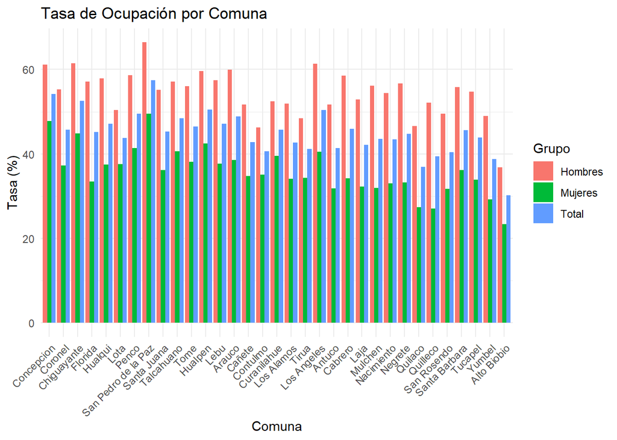

```r
grafico_tasas_ocupacion <- ggplot(df_o, aes(x = comuna, y = tasa, fill = grupo)) +
                          geom_col(position = position_dodge()) +
                          labs(title = "Tasa de Ocupación por Comuna",
                           x = "Comuna",
                           y = "Tasa (%)",
                           fill = "Grupo") +
                         theme_minimal() +
                         theme(axis.text.x = element_text(angle = 45, hjust = 1))

grafico_tasas_ocupacion
```

**Mostrar/ocultar código**

```r
df_oc<-filter(df_o, grupo=="Total" )
df_oc<-arrange(df_oc,-tasa )
```

La comuna con mayor tasa de ocupación es San Pedro de la Paz con 57.5 %, mientras que la menor tasa de ocupación se registró en Alto Biobio con 30.1 %.

## Tasa de participación a nivel comunal

**Mostrar/ocultar código**

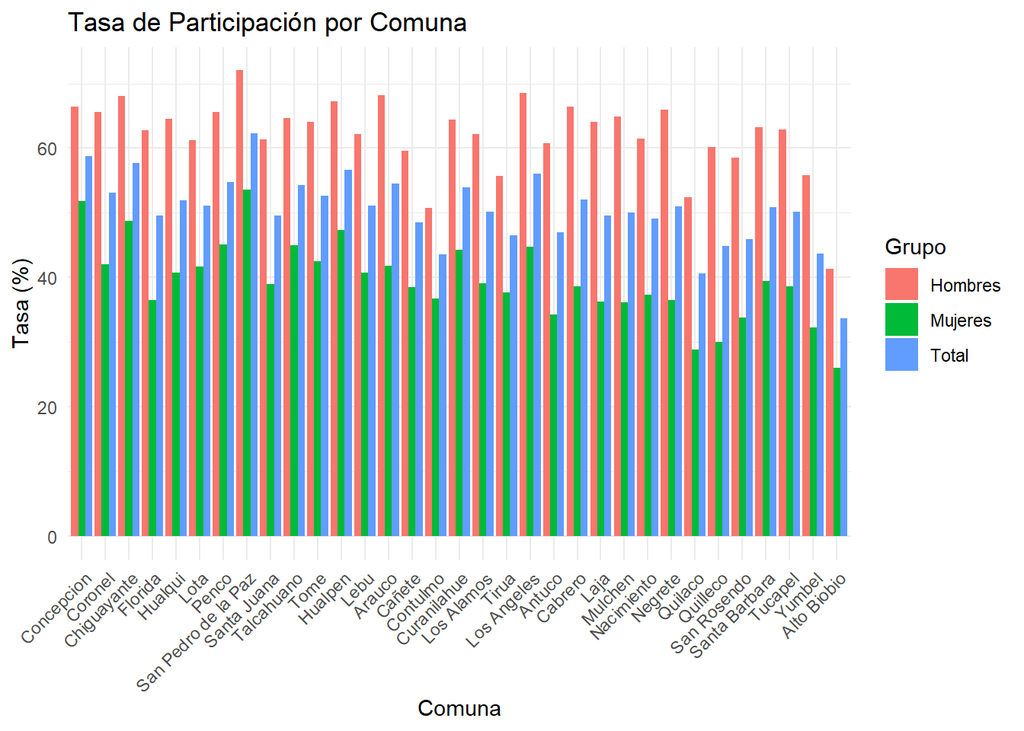

```r
grafico_tasas_participacion <- ggplot(df_p, aes(x = comuna, y = tasa, fill = grupo)) +
                              geom_col(position = position_dodge()) +
                              labs(title = "Tasa de Participación por Comuna",
                               x = "Comuna",
                               y = "Tasa (%)",
                               fill = "Grupo") +
                             theme_minimal() +
                             theme(axis.text.x = element_text(angle = 45, hjust = 1))

grafico_tasas_participacion
```

**Mostrar/ocultar código**

```r
df_pc<-filter(df_p, grupo=="Total" )
df_pc<-arrange(df_pc,-tasa )
```

La comuna con mayor tasa de participación San Pedro de la Paz con 62.2 %, mientras que la menor tasa de participación se registró en Alto Biobio con 33.7 %.

# Conclusiones

En este documento se han presentado indicadores laborales para las comunas de la Región del Biobío, desagregados por sexo, con el fin de aplicar los contenidos entregados en el curso Análisis de datos con R Intermedio.

En el caso de las tasas de ocupación y participación, se aprecia un patrón similar al de las estimaciones a partir de la Encuesta Nacional de Empleo (ENE), es decir, grandes brechas en desmedro de las mujeres respecto de los hombres.

Sin embargo, en el caso de la tasa de desocupación, a diferencia de la ENE, la brecha entre hombres y mujeres en la tasa de desocupación es en desmedro de los hombres, es decir, éstos presentan una tasa de desocupación mayor que en el caso de las mujeres. Una hipótesis que podría explicar estas diferencias, y que puede ser parte de un estudio futuro, es la forma diferente en que se indaga acerca de la situación laboral de las personas, ya sea en el fraseo de las preguntas, flujo del cuestionario, entre otros.

En cualquier caso, es importante recalcar que la operación estadística que entrega cifras oficiales respecto de la situación de la población en edad de trabajar (PET) en el mercado laboral, es justamente la Encuesta Nacional de Empleo del INE.